# 07 · Topic deep dive — BERTopic (canonical)

Deep dive into the **canonical** topic model: BERTopic (SPECTER2 → UMAP → HDBSCAN → c-TF-IDF), fitted offline by `src/topics_bertopic.py` at `min_cluster_size=25, seed=42` on the M2-enriched corpus (2,676 grants + 65 orphan pseudo-docs). **25 topics + an honest "Unassigned" (noise) cluster**, grouped under 8 parent themes. LDA is retired (kept only in `src/topics_lda.py` for continuity).

```python
import warnings; warnings.filterwarnings('ignore')
import json
from pathlib import Path
import numpy as np, pandas as pd
import matplotlib.pyplot as plt
import seaborn as sns
import plotly.express as px
from scipy.cluster.hierarchy import linkage, dendrogram
from bertopic import BERTopic

sns.set_theme(style='whitegrid'); plt.rcParams['figure.dpi'] = 110

REPO_ROOT = Path.cwd().resolve()
while not (REPO_ROOT / 'data' / 'processed').exists() and REPO_ROOT != REPO_ROOT.parent:
    REPO_ROOT = REPO_ROOT.parent
PROCESSED = REPO_ROOT / 'data' / 'processed'
OUTPUTS   = REPO_ROOT / 'outputs'; OUTPUTS.mkdir(exist_ok=True)
DOCS      = REPO_ROOT / 'docs';    DOCS.mkdir(exist_ok=True)
FIG_DIR   = REPO_ROOT / 'notebooks' / 'figures'; FIG_DIR.mkdir(parents=True, exist_ok=True)
assert PROCESSED.exists()
```

## 0 · Load the canonical model + assignments + labels

```python
faculty = pd.read_parquet(PROCESSED / 'faculty.parquet')
grants  = pd.read_parquet(PROCESSED / 'grants.parquet')
fg      = pd.read_parquet(PROCESSED / 'faculty_grants.parquet')
ta      = pd.read_parquet(PROCESSED / 'topic_assignments.parquet')
for d, cols in [(grants, ['grant_id']), (fg, ['grant_id', 'faculty_id']),
                (faculty, ['faculty_id']), (ta, ['doc_id'])]:
    for c in cols:
        d[c] = d[c].astype(str)

topic_model = BERTopic.load(str(PROCESSED / 'bertopic_model'))
labels  = json.load(open(OUTPUTS / 'topic_labels.json', encoding='utf-8'))
TL, PARENTS = labels['topics'], labels['parents']
id2label  = {int(k): v['label'] for k, v in TL.items()}
id2parent = {int(k): (PARENTS[v['parent']]['label'] if v['parent'] else None)
             for k, v in TL.items()}

# grant-level topic (exclude the orphan-* pseudo-docs), + lead-PI college
gt = ta[~ta['is_extra']][['doc_id', 'topic_id']].rename(columns={'doc_id': 'grant_id'})
g = grants.merge(gt, on='grant_id', how='left')
g['topic_id']    = g['topic_id'].fillna(-1).astype(int)
g['topic_label'] = g['topic_id'].map(id2label).fillna('Unassigned')
g['parent']      = g['topic_id'].map(id2parent).fillna('Unassigned')
lead = fg[fg['is_pi']].merge(faculty[['faculty_id', 'superior_academic_unit']],
                             on='faculty_id', how='left')
g['college'] = g['grant_id'].map(lead.groupby('grant_id')['superior_academic_unit'].first()).astype('object')

diag = json.load(open(OUTPUTS / 'bertopic_diagnostics.json'))
print(f"BERTopic: {diag['n_topics']} topics | {diag['pct_noise']}% noise "
      f"({diag['n_noise']}/{diag['n_docs']}) | intra-cosine {diag['mean_intra_cluster_cosine']}")
print(f"grants: {len(g)} | assigned to a topic: {(g.topic_id>=0).sum()} | "
      f"unassigned: {(g.topic_id==-1).sum()}")
display(topic_model.get_topic_info()[['Topic', 'Count', 'Name']].head(26))
```

```
BERTopic: 25 topics | 28.31% noise (776/2741) | intra-cosine 0.9338
grants: 2676 | assigned to a topic: 1930 | unassigned: 746
```

|  | Topic | Count | Name |
| --- | --- | --- | --- |
| 0 | -1 | 776 | -1_cells_cell_learning_health |
| 1 | 0 | 266 | 0_materials_quantum_magnetic_spin |
| 2 | 1 | 255 | 1_learning_brain_robots_cognitive |
| 3 | 2 | 131 | 2_theory_physics_algebras_quantum |
| 4 | 3 | 116 | 3_protein_proteins_dna_biological |
| 5 | 4 | 107 | 4_cancer_tumor_delivery_drug |
| 6 | 5 | 94 | 5_marine_ocean_species_ecosystem |
| 7 | 6 | 85 | 6_wireless_spectrum_networks_network |
| 8 | 7 | 74 | 7_faculty_stem_education_icorps |
| 9 | 8 | 70 | 8_security_privacy_attacks_hardware |
| 10 | 9 | 65 | 9_health_patients_delirium_risk |
| 11 | 10 | 63 | 10_wind_energy_buildings_structural |
| 12 | 11 | 62 | 11_fisheries_cholesterol_follicles_natural human |
| 13 | 12 | 61 | 12_brain_cardiac_channel_activity |
| 14 | 13 | 60 | 13_software_languages_programming_language |
| 15 | 14 | 58 | 14_tissue_cell_stem_cells |
| 16 | 15 | 56 | 15_networks_network_social_algorithms |
| 17 | 16 | 55 | 16_addiction_receptors_ligands_drug |
| 18 | 17 | 54 | 17_water_coastal_flood_flooding |
| 19 | 18 | 45 | 18_compounds_bacteria_microorganisms_antibiotics |
| 20 | 19 | 41 | 19_underwater_acoustic_ocean_marine |
| 21 | 20 | 37 | 20_trafficking_mobility_social_supply |
| 22 | 21 | 30 | 21_control_power_robust_optimization |
| 23 | 22 | 28 | 22_environmental_health_chemicals_social |
| 24 | 23 | 27 | 23_computing_cloud_storage_biomedical imaging |
| 25 | 24 | 25 | 24_learning_game_physical activity_computer |

## 1 · Topic prevalence

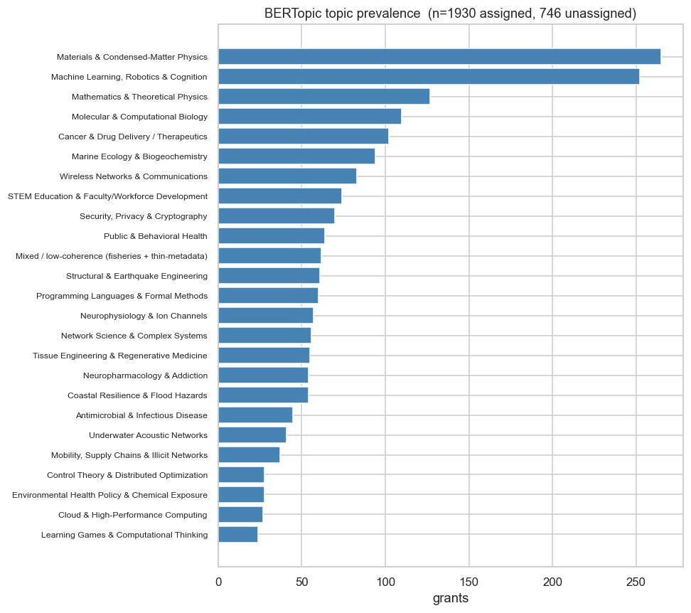

```python
sizes = g[g.topic_id >= 0].groupby('topic_id').size().sort_values(ascending=False)
fig, ax = plt.subplots(figsize=(9, 8))
ax.barh(range(len(sizes)), sizes.values, color='steelblue')
ax.set_yticks(range(len(sizes))); ax.set_yticklabels([id2label[t] for t in sizes.index], fontsize=8)
ax.invert_yaxis(); ax.set_xlabel('grants')
ax.set_title(f'BERTopic topic prevalence  (n={(g.topic_id>=0).sum()} assigned, '
             f'{(g.topic_id==-1).sum()} unassigned)')
plt.tight_layout(); plt.savefig(FIG_DIR / 'w7_topic_prevalence.png', dpi=120, bbox_inches='tight'); plt.show()
```

## 2 · What does each college work on? (topics × college, row-normalised)

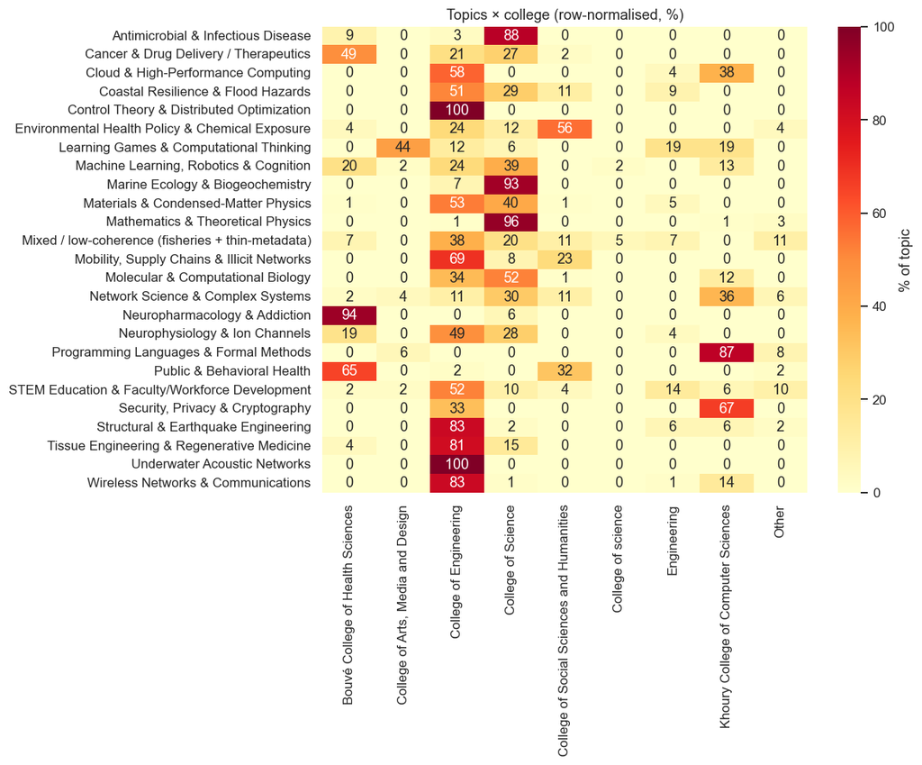

```python
sub = g[(g.topic_id >= 0) & g.college.notna()].copy()
top_colleges = sub.college.value_counts().head(8).index.tolist()
sub['col2'] = sub.college.where(sub.college.isin(top_colleges), 'Other')
ct  = pd.crosstab(sub.topic_label, sub.col2)
ctn = ct.div(ct.sum(axis=1), axis=0) * 100    # each topic sums to 100% across colleges
fig, ax = plt.subplots(figsize=(11, 9))
sns.heatmap(ctn, annot=True, fmt='.0f', cmap='YlOrRd', cbar_kws={'label': '% of topic'}, ax=ax)
ax.set_title('Topics × college (row-normalised, %)'); ax.set_xlabel(''); ax.set_ylabel('')
plt.tight_layout(); plt.savefig(FIG_DIR / 'w7_topic_by_college_rownorm.png', dpi=120, bbox_inches='tight'); plt.show()
```

## 3 · College profiles — top topics, agencies, PIs

```python
fg_full = fg.merge(g[['grant_id', 'topic_id', 'topic_label', 'college', 'totaldollars']],
                   on='grant_id', how='inner')
rows = []
for col in top_colleges:
    cg = g[(g.college == col) & (g.topic_id >= 0)]
    tt = cg.topic_label.value_counts().head(3)
    ta_ = cg.agencyname.value_counts().head(3)
    pis = (fg_full[(fg_full.college == col) & fg_full.is_pi]
           .groupby('faculty_name')['totaldollars'].sum().sort_values(ascending=False).head(5))
    rows.append({'college': col, 'n_grants': len(cg),
                 'total_$M': round(cg.totaldollars.sum() / 1e6, 1),
                 'top_topics': ' | '.join(f'{k} ({v})' for k, v in tt.items()),
                 'top_agencies': ' | '.join(f'{k} ({v})' for k, v in ta_.items()),
                 'top_PIs': ' | '.join(f'{k} (${v/1e6:.1f}M)' for k, v in pis.items())})
prof = pd.DataFrame(rows).sort_values('total_$M', ascending=False).reset_index(drop=True)
prof.to_csv(OUTPUTS / 'college_profiles.csv', index=False)
display(prof[['college', 'n_grants', 'total_$M', 'top_topics', 'top_agencies']])
```

|  | college | n_grants | total_$M | top_topics | top_agencies |
| --- | --- | --- | --- | --- | --- |
| 0 | College of Engineering | 605 | 465.2 | Materials & Condensed-Matter Physics (128) \| W... | National Science Foundation (427) \| National I... |
| 1 | College of Science | 548 | 374.7 | Mathematics & Theoretical Physics (111) \| Mate... | National Science Foundation (322) \| National I... |
| 2 | Bouvé College of Health Sciences | 200 | 278.9 | Neuropharmacology & Addiction (48) \| Machine L... | National Institutes of Health (139) \| National... |
| 3 | Khoury College of Computer Sciences | 178 | 81.5 | Programming Languages & Formal Methods (46) \| ... | National Science Foundation (152) \| National I... |
| 4 | Engineering | 35 | 26.8 | Materials & Condensed-Matter Physics (11) \| ST... | National Science Foundation (25) \| Office of N... |
| 5 | College of Social Sciences and Humanities | 60 | 20.6 | Public & Behavioral Health (18) \| Environmenta... | National Science Foundation (30) \| National In... |
| 6 | College of science | 7 | 17.7 | Machine Learning, Robotics & Cognition (4) \| M... | National Institutes of Health (4) \| Office of ... |
| 7 | College of Arts, Media and Design | 17 | 12.6 | Learning Games & Computational Thinking (7) \| ... | National Science Foundation (12) \| National In... |

## 4 · Topic hierarchy — 8 parent themes

|  | parent | n_topics | n_grants | topics |
| --- | --- | --- | --- | --- |
| 0 | Physical Sciences & Engineering | 3 | 453 | Materials & Condensed-Matter Physics, Mathemat... |
| 1 | Life Sciences & Biomedicine | 6 | 423 | Molecular & Computational Biology, Cancer & Dr... |
| 2 | AI, Robotics & Cognition | 1 | 252 | Machine Learning, Robotics & Cognition |
| 3 | Environment, Ocean & Climate | 4 | 217 | Marine Ecology & Biogeochemistry, Coastal Resi... |
| 4 | Networks, Signals & Control | 3 | 167 | Wireless Networks & Communications, Network Sc... |
| 5 | Computing & Cybersecurity | 3 | 157 | Security, Privacy & Cryptography, Programming ... |
| 6 | Society, Health & Mobility | 2 | 101 | Public & Behavioral Health, Mobility, Supply C... |
| 7 | Education & Learning | 2 | 98 | STEM Education & Faculty/Workforce Development... |

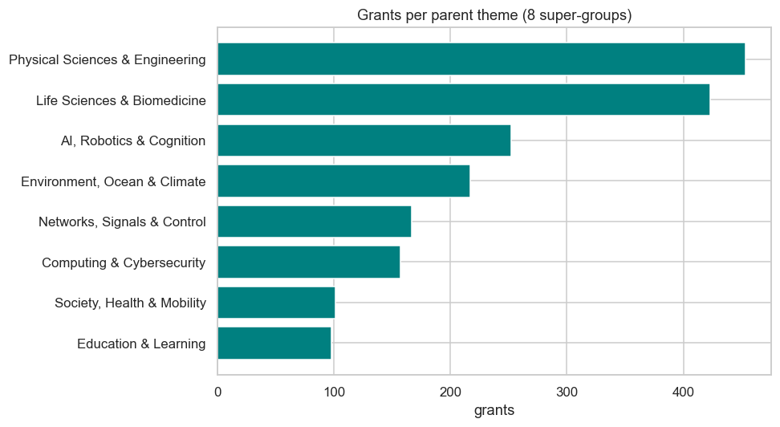

```python
prows = []
for pid, p in PARENTS.items():
    tids = p['topic_ids']
    prows.append({'parent': p['label'], 'n_topics': len(tids),
                  'n_grants': int(g[g.topic_id.isin(tids)].shape[0]),
                  'topics': ', '.join(id2label[t] for t in tids)})
parent_df = pd.DataFrame(prows).sort_values('n_grants', ascending=False).reset_index(drop=True)
display(parent_df)
ps = parent_df.sort_values('n_grants')
fig, ax = plt.subplots(figsize=(9, 5))
ax.barh(ps.parent, ps.n_grants, color='teal')
ax.set_xlabel('grants'); ax.set_title('Grants per parent theme (8 super-groups)')
plt.tight_layout(); plt.savefig(FIG_DIR / 'w7_parent_sizes.png', dpi=120, bbox_inches='tight'); plt.show()
```

## 5 · Topic similarity dendrogram (SPECTER2 centroids)

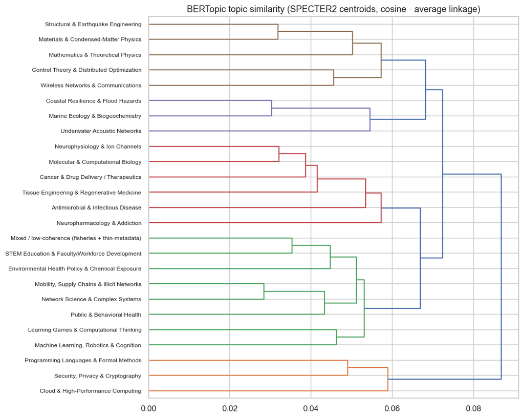

```python
emb = np.load(PROCESSED / 'specter2_embeddings.npy')
ids = (PROCESSED / 'specter2_ids.txt').read_text().splitlines()
id2row = {s: i for i, s in enumerate(ids)}
norm = emb / (np.linalg.norm(emb, axis=1, keepdims=True) + 1e-9)
tids = sorted(t for t in g.topic_id.unique() if t >= 0)
cent = np.vstack([norm[[id2row[d] for d in g[g.topic_id == t].grant_id if d in id2row]].mean(0)
                  for t in tids])
Z = linkage(cent, method='average', metric='cosine')
fig, ax = plt.subplots(figsize=(10, 8))
dendrogram(Z, labels=[id2label[t] for t in tids], orientation='right', leaf_font_size=8, ax=ax)
ax.set_title('BERTopic topic similarity (SPECTER2 centroids, cosine · average linkage)')
plt.tight_layout(); plt.savefig(FIG_DIR / 'w7_topic_dendrogram.png', dpi=120, bbox_inches='tight'); plt.show()
```

## 6 · UMAP projection (canonical SPECTER2 coords)

Uses the committed 2-D UMAP (`specter2_umap_2d.npy`) — the *same* coordinates the `grant_atlas` app renders, so this lines up with the interactive viz.

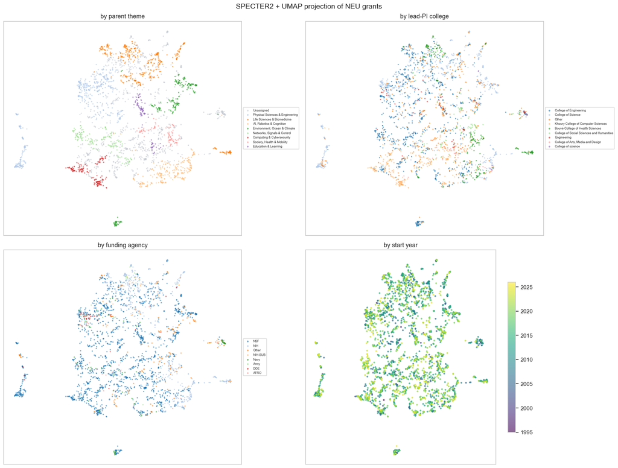

```python
umap2d = np.load(PROCESSED / 'specter2_umap_2d.npy')
udf = pd.DataFrame({'doc_id': ids, 'x': umap2d[:, 0], 'y': umap2d[:, 1]})
udf = udf[~udf.doc_id.str.startswith('orphan-')]      # grants only
udf = udf.merge(g[['grant_id', 'topic_id', 'topic_label', 'parent', 'college',
                   'agencyname', 'startdateyear', 'grantname']],
                left_on='doc_id', right_on='grant_id', how='left')

def _bucket(a):
    a = str(a).lower()
    for key, lab in [('national science', 'NSF'), ('subaward', 'NIH-SUB'),
                     ('national institutes', 'NIH'), ('nav', 'Navy'), ('nasa', 'NASA'),
                     ('army', 'Army'), ('energy', 'DOE'), ('air force', 'AFRO')]:
        if key in a:
            return lab
    return 'Other'
udf['agency_grp'] = udf.agencyname.map(_bucket)
udf['college_grp'] = udf.college.where(udf.college.isin(top_colleges), 'Other')

def _scat(ax, col, title, cont=False):
    if cont:
        s = ax.scatter(udf.x, udf.y, c=udf[col], s=6, cmap='viridis', alpha=0.6)
        plt.colorbar(s, ax=ax, shrink=0.7)
    else:
        cats = udf[col].fillna('Unassigned').astype(str)
        order = cats.value_counts().index.tolist()
        pal = sns.color_palette('tab20', len(order))
        for c, color in zip(order, pal):
            m = cats == c
            ax.scatter(udf.loc[m, 'x'], udf.loc[m, 'y'], s=6, alpha=0.6,
                       color=('#c7ccd3' if c == 'Unassigned' else color), label=c, linewidths=0)
        ax.legend(fontsize=6, markerscale=1.4, loc='center left', bbox_to_anchor=(1.0, 0.5))
    ax.set_title(title); ax.set_xticks([]); ax.set_yticks([])

fig, axes = plt.subplots(2, 2, figsize=(17, 13))
_scat(axes[0, 0], 'parent', 'by parent theme')
_scat(axes[0, 1], 'college_grp', 'by lead-PI college')
_scat(axes[1, 0], 'agency_grp', 'by funding agency')
_scat(axes[1, 1], 'startdateyear', 'by start year', cont=True)
fig.suptitle('SPECTER2 + UMAP projection of NEU grants', fontsize=14)
plt.tight_layout(); plt.savefig(FIG_DIR / 'w7_umap_grants_specter2.png', dpi=120, bbox_inches='tight'); plt.show()
```

### Interactive projection (coloured by topic) → `docs/07_grant_projection_specter2.html`

```python
pdf = udf.copy()
pdf['topic_label'] = pdf.topic_label.fillna('Unassigned')
pdf['title'] = pdf.grantname.astype(str).str[:110]
fig = px.scatter(pdf, x='x', y='y', color='topic_label', hover_name='title',
                 hover_data={'x': False, 'y': False, 'agencyname': True,
                             'startdateyear': True, 'college': True},
                 title='SPECTER2 + UMAP · NEU grants coloured by BERTopic topic',
                 width=1050, height=720, opacity=0.65)
fig.update_traces(marker=dict(size=5))
fig.update_layout(legend=dict(font=dict(size=9)))
fig.write_html(DOCS / '07_grant_projection_specter2.html')
print('wrote', DOCS / '07_grant_projection_specter2.html')
fig.show()
```

```
wrote D:\Projects\northeastern_visualization\docs\07_grant_projection_specter2.html
```

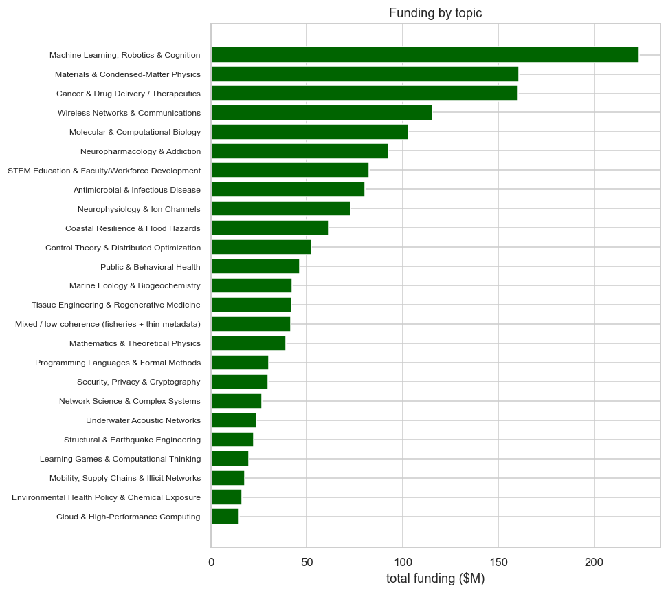

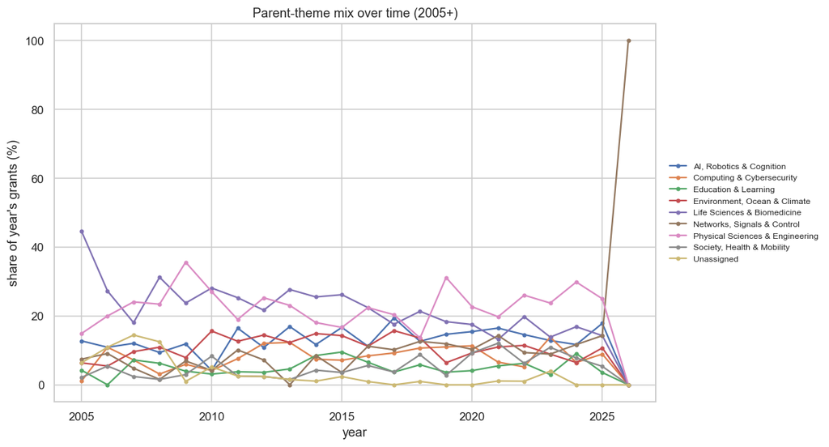

```python
tg = g[g.topic_id >= 0].copy()
# funding per topic ($M) + avg grant size
fund = tg.groupby('topic_label')['totaldollars'].agg(['sum', 'mean', 'size'])
fund['sum'] /= 1e6; fund['mean'] /= 1e6
fund = fund.sort_values('sum', ascending=False)
fig, ax = plt.subplots(figsize=(9, 8))
ax.barh(range(len(fund)), fund['sum'], color='darkgreen')
ax.set_yticks(range(len(fund))); ax.set_yticklabels(fund.index, fontsize=8); ax.invert_yaxis()
ax.set_xlabel('total funding ($M)'); ax.set_title('Funding by topic')
plt.tight_layout(); plt.savefig(FIG_DIR / 'w7_topic_funding.png', dpi=120, bbox_inches='tight'); plt.show()

# topics over time (share of year), 2005+
tt = tg[tg.startdateyear >= 2005]
trend = pd.crosstab(tt.startdateyear, tt.parent)
trend_pct = trend.div(trend.sum(axis=1), axis=0) * 100
fig, ax = plt.subplots(figsize=(11, 6))
for c in trend_pct.columns:
    ax.plot(trend_pct.index, trend_pct[c], marker='o', markersize=3, linewidth=1.5, label=c)
ax.set_xlabel('year'); ax.set_ylabel("share of year's grants (%)")
ax.set_title('Parent-theme mix over time (2005+)')
ax.legend(loc='center left', bbox_to_anchor=(1.01, 0.5), fontsize=8, frameon=False)
plt.tight_layout(); plt.savefig(FIG_DIR / 'w7_parent_over_time.png', dpi=120, bbox_inches='tight'); plt.show()
```

## Deliverables

- Figures (`notebooks/figures/`): `w7_topic_prevalence`, `w7_topic_by_college_rownorm`, `w7_parent_sizes`, `w7_topic_dendrogram`, `w7_umap_grants_specter2`, `w7_topic_funding`, `w7_parent_over_time`.
- `outputs/college_profiles.csv`
- `docs/07_grant_projection_specter2.html` — interactive projection coloured by BERTopic topic.

All driven by the canonical BERTopic model; the LDA path is retired (see `src/topics_lda.py` for the legacy fit and `TOPIC_WORK_FORWARD_PLAN.md` M5b for the planned LDA-vs-BERTopic agreement crosstab).